# Local Elections and the Mexican Drug War

Marco Alcocer

March 1, 2018

*This short blog is replicating the regression discontinuity in:* *Dell, Melissa. 2015. “Trafficking Networks and the Mexican Drug War.” American Economic Review 105(6): 1738-79.*

### Introduction

Does cracking down on drug trafficking organization inadvertently cause violence to increase?

In December of 2006, the newly elect President of Mexico Felipe Calderon declared war against organized crime and deployed the military to combat these groups. While the motivation behind this action is contested, the expectation was that a crackdown would fragment and weaken criminal organizations enough to prevent them from undermining political institutions through corruption or violence. However, starting in 2007 Mexico witnessed an unprecedented increase in drug-related violence that still plagues the country. But why did Mexico become so violent?

Prevalent theories about why Mexico became so violent after the crackdown on drug cartels in 2006 point to the crackdown itself. These theories argue that the crackdown *did* fragment criminal organizations, but did not weaken them sufficiently to usurp their power. This fragmentation, rather than leading to weak criminal organizations trafficking drugs in relative peace, intensified competition in the trafficking market between powerful criminal organizations. This surge in illicit market competition–largely caused by the crackdown–led to drastic increases in violence throughout the country.

Given the partisan nature of Mexican politics, it might be reasonable to assume that local elected officials from the PAN party actively participated in the newly-elected president’s crackdown given the pressure to make their party’s new policy a success. Inversely, local officials from opposition parties had little incentive to cooperate and implement the new policy, especially the PRD, who had just lost the presidency by less than 1% of the votes.

If we accept these assumptions, we should expect that municipalities with PAN elected officials cracked down on organized crime starting in December of 2006, while municipalities ruled by opposition parties did not. Additionally, since we have sufficient evidence that increased enforcement against organized crime led to a rise in violence in Mexico over the past decade, we should expect that municipalities with PAN elected officials experienced higher levels of violence than municipalities controlled by the opposition.

### Research Design

To test the hypothesis proposed above, we can use a regression discontinuity design to look at local elections and compare levels of violence in municipalities where PAN won versus where the opposition won. We can use an RD design if we assume that the outcomes of closely contested elections resulted from idiosyncratic factors, which in the case of Mexico is a reasonable assumption. By using an RDD however, we discard elections that were not closely contested since they could differ systematically from those that were closely contested. We therefore cannot generalize the results of this research onto elections in general. For this analysis I define competitive elections as those with a vote spread of 5% or less.

### Results

To implement the RDD described above, I use data from the Mexican electoral agency (INE) on 152 municipal elections that occurred between 2007 and 2008 where the PAN won or lost by a 5% margin or less. I also use monthly data on municipal homicide rates (homicides per 100,000) from the Mexican Office of the President. Finally, the covariate data comes from the Mexican National Statistical Agency (INEGI).

I first offer the covariate balance table comparing municipalities where PAN won and where PAN lost. The table shows the mean for treated and control groups, along with the standard mean difference and the corresponding p-value. As can be seen, the covariates are fairly balanced.

**Covariate Balance (5% vote spread)**

|  | PAN won | PAN lost | Standard means difference | P-value |
| --- | --- | --- | --- | --- |
| Detour length (km) | 26.146 | 22.478 | 2.744 | 0.847 |
| Surface area (km2) | 1,787.360 | 725.375 | 16.431 | 0.180 |
| Average precipitation, cm | 1,164.399 | 1,084.634 | 9.592 | 0.516 |
| Average max. temperature, C | 22.536 | 22.897 | -8.669 | 0.594 |
| Average min. temperature, C | 7.167 | 7.594 | -7.908 | 0.643 |
| Elevation (m) | 1,403.418 | 1,367.947 | 4.279 | 0.799 |
| Slope (degrees) | 3.621 | 3.186 | 16.232 | 0.307 |
| % alternations (1976-2006) | 0.310 | 0.315 | -3.006 | 0.853 |
| PAN incumbent | 0.271 | 0.317 | -10.191 | 0.541 |
| PRD incumbent | 0.171 | 0.134 | 9.821 | 0.529 |
| PRI never lost (1976-2006) | 0.071 | 0.073 | -0.672 | 0.967 |
| Marginality index (2005) | -0.154 | -0.119 | -3.865 | 0.816 |
| Population (2005) | 6.026 | 5.099 | 4.810 | 0.727 |
| Income per capita level (2005) | 4.285 | 4.483 | -8.281 | 0.595 |
| Mun. taxes per capita (2005) | 59.845 | 56.746 | 3.221 | 0.821 |
| Population density (2005) | 220.232 | 191.051 | 6.852 | 0.677 |
| Migrants per capita (2005) | 0.016 | 0.018 | -11.533 | 0.490 |
| Malnutrition (2005) | 32.760 | 31.198 | 8.735 | 0.599 |
| Mean years schooling (2005) | 6.262 | 6.186 | 5.321 | 0.746 |
| Infant mortality (2005) | 22.538 | 22.263 | 3.969 | 0.826 |
| HH w/o access to sewage (2005) | 8.505 | 8.436 | 0.845 | 0.958 |
| HH w/o access to water (2005) | 16.141 | 18.221 | -10.419 | 0.535 |
| Distance U.S. (km) | 708.270 | 735.487 | -8.412 | 0.586 |
| Road density (km/km2) | 0.151 | 0.131 | 14.157 | 0.329 |
| *Observations*: Total = 152; PAN won = 72; PAN lost = 80. |  |  |  |  |

Given that the treatment and control groups are balanced, I now analyze the effects of elections on violence.

If local crackdowns are affecting levels of violence, I expect that these effects would only occur *after* the inauguration of the new municipal president and not before that. I therefore provide results of close elections on homicide rates during four different time periods–before the elections, during the lame duck period, the six months following the inauguration, and the entire mayoral term.

For each time period I present the results of a linear model and a quadratic model, with each observation weighted by the population size of the municipality since homicide reporting has a lower variance in urban areas (this is standard practice in the crime literature). I also provide graphs visualizing these results using the quadratic model.

Results:

- The first RD results show no difference in homicide rates before the elections, as we expected
- The second RD results show no difference in homicide rates during the lame duck period–the three to five month period between the elections and the inauguration of the new municipal president–which we also expected
- The third RD results show a noticeable increase in homicide rates during the first six months of the PAN municipal president’s term. This translates to an average increase of about 14-17 in the homicide rates of municipalities where the PAN won close elections
- Finally, as expected, the last RD results show a substantial increase in homicide rates in municipalities where the PAN won contested elections. The results translate to about a 56-68 point increase in the homicide rate following PAN victories. These are extreme results considering that the average homicide rate in Mexico in 2007 was 9.3, and the sample median was 8.7 after inauguration.

**Close PAN elections and Homicide rates: 2007-2008 Elections**

|  | Homicide rate |  |  |  |
| --- | --- | --- | --- | --- |
|  | Before elections | Lame duck period | First six months in office | Entire term |
|  | (1) | (2) | (3) | (4) |
| PAN win (linear) | 3.088 | 2.457 | 17.133*** | 56.630*** |
|  | (4.873) | (3.044) | (5.812) | (15.536) |
| PAN win (quadratic) | -1.951 | 4.442 | 14.200*** | 68.550*** |
|  | (6.703) | (3.770) | (5.502) | (14.745) |
| Observations | 152 | 152 | 152 | 152 |
| *Note:* | p<0.1; p<0.05; p<0.01 |  |  |  |

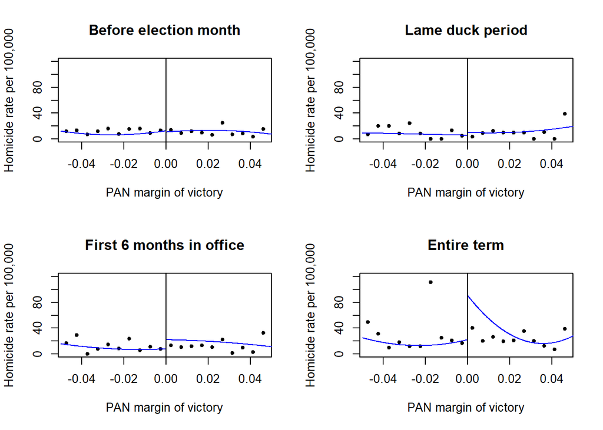

#### Robustness check

**Close PAN elections and Homicide rates: 2007-2008 Elections (bw of 0.03)**

|  | Homicide rate |  |  |  |
| --- | --- | --- | --- | --- |
|  | Before elections | Lame duck period | First six months in office | Entire term |
|  | (1) | (2) | (3) | (4) |
| PAN win (linear) | 2.200 | 3.725 | 17.237*** | 68.026*** |
|  | (5.190) | (2.291) | (5.411) | (14.229) |
| PAN win (quadratic) | -4.500 | 0.817 | 8.725 | 64.872** |
|  | (5.720) | (4.071) | (5.490) | (26.722) |
| Observations | 130 | 130 | 130 | 130 |
| *Note:* | p<0.1; p<0.05; p<0.01 |  |  |  |

I also conducted two placebo tests using the bandwidth of 0.03, but moving the cutoff 0.02 degrees left or right. Ideally, there should not be jumps at the new cutoffs, but there are, so I don’t report the results. However, this is likely due to the relatively small shifts in cutoffs I’m constricted to with the dataset.

### Potential issues

There are two major potential issues that I want to explore:

1. Close elections might affect homicide rates in municipalities where drug cartels operate, but not in municipalities where cartels do not operate.
2. If the results are driven by a few observations, and these observations are where the military intervened, municipal elections might not be the source underlying the spike in violence.

#### Cartel presence

The first issue is that drug cartels do not operate in every municipality in Mexico. How could a close PAN victory at the municipal level increase violence as a result of a crackdown on drug cartels if there are no drug cartels to crack down on?

Thus, close elections might have an effect in municipalities where drug cartels operate, but not where they don’t.

To test this hypothesis, I use a dataset that determines what municipalities cartels operate in using web content (Coscia and Rios 2012). Using this dataset, I run two separate RDs, one with municipalities that had cartel presence in the 2007-2008 period, and another where they did not.

The results, shown below, confirm my intuition: close elections in municipalities where cartels operate have a significant and positive effect on homicide rates, but have no effect in municipalities where cartels do not operate.

**Close PAN elections and Homicide rates: 2007-2008 Elections**

|  | Homicide rate |  |  |  |
| --- | --- | --- | --- | --- |
|  | Cartel presence |  | No cartel presence |  |
|  | Before inauguration | After inauguration | Before inauguration | After inauguration |
|  | (1) | (2) | (3) | (4) |
| PAN win (linear) | 2.573 | 63.181*** | -1.218 | -7.031 |
|  | (5.987) | (13.356) | (3.310) | (8.238) |
| PAN win (quadratic) | -4.648 | 69.027*** | 2.748 | 9.703 |
|  | (7.715) | (12.228) | (5.483) | (12.286) |
| Observations | 47 | 47 | 105 | 105 |
| *Note:* | p<0.1; p<0.05; p<0.01 |  |  |  |

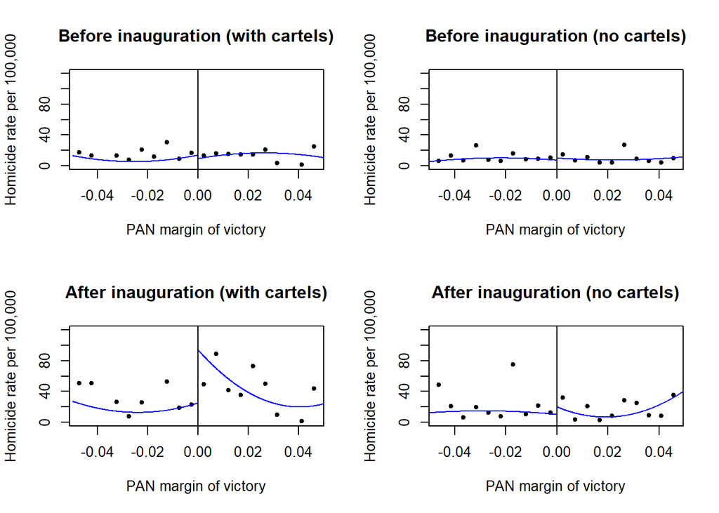

#### Militarization

A second potential issue might be that the main results are driven by a handful of observations.

Here I explore this possibility:

The table below gives a summary of the homicide rates before and after the inauguration, with the plots under it visualizing the homicide rate densities and homicide rates before versus after inauguration, with the diagonal line representing no change.

The density plots and the first scatterplot show that there’s clearly a small number of observations whose homicide rates are considerably higher than the rest. The second scatterplot re-scales the axes to see the bottom cluster of observations better and reveals homicide rates having no obvious pattern of a partisan divide.

**Homicide rate summary**

|  | Min. | 1st Qu. | Median | Mean | 3rd Qu. | Max |
| --- | --- | --- | --- | --- | --- | --- |
| Before inauguration | 0 | 3.72 | 7.82 | 12.01 | 14.43 | 132.34 |
| After inauguration | 0 | 3.89 | 8.74 | 26.98 | 28.4 | 263.05 |

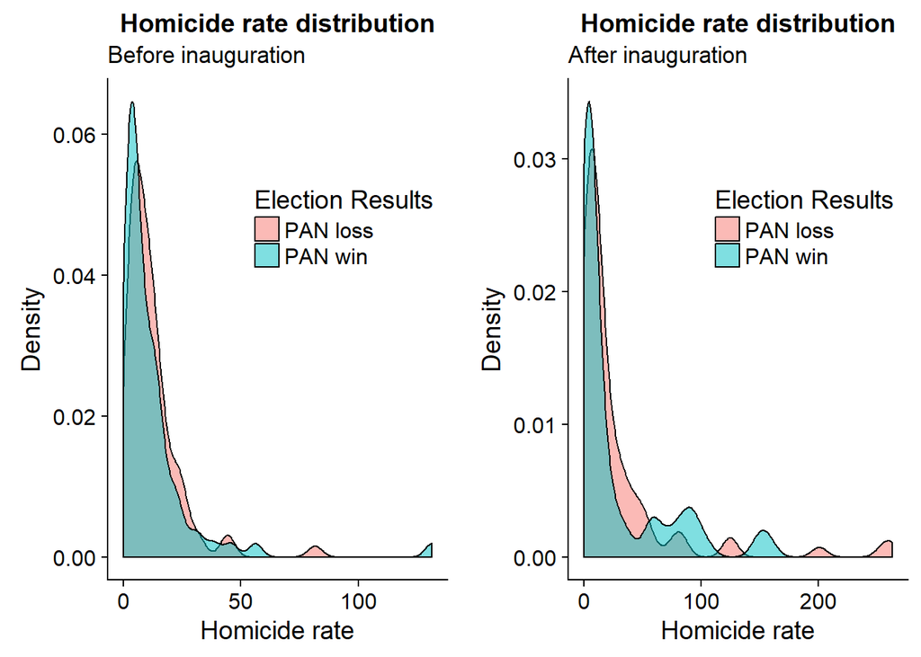

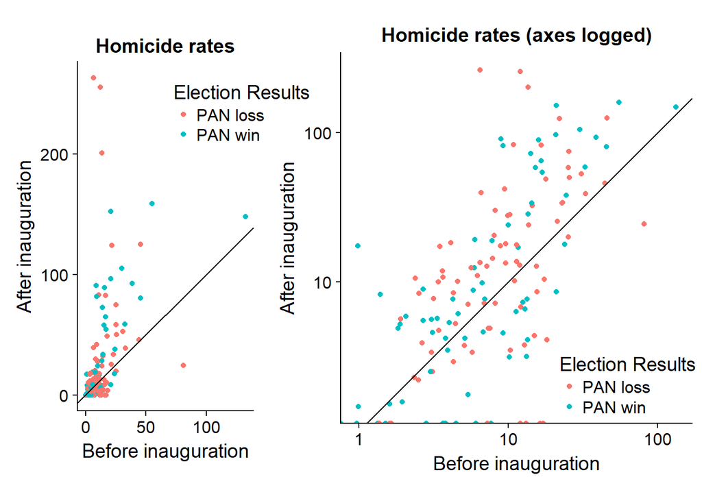

Having suggestive evidence that the results might depend on a few observations, I list the top 10% most violent municipalities post-inauguration below. Interestingly, 11 of the 15 most violent municipalities are in the state of Chihuahua.

|  | PAN win | Homicide rate | Municipality | State |
| --- | --- | --- | --- | --- |
| 1 | 0 | 263.05 | Aquiles Serdán | Chihuahua |
| 2 | 0 | 255.08 | Matamoros | Chihuahua |
| 3 | 0 | 200.51 | Santa Isabel | Chihuahua |
| 4 | 1 | 158.83 | Moris | Chihuahua |
| 5 | 1 | 152.29 | Satevó | Chihuahua |
| 6 | 1 | 148.03 | Uruachi | Chihuahua |
| 7 | 0 | 125.21 | Guachochi | Chihuahua |
| 8 | 0 | 124 | El Oro | Durango |
| 9 | 1 | 105.05 | Temósachic | Chihuahua |
| 10 | 1 | 96.54 | Cuajinicuilapa | Guerrero |
| 11 | 1 | 92.59 | San Dimas | Durango |
| 12 | 1 | 90.95 | Chihuahua | Chihuahua |
| 13 | 1 | 89.04 | Hidalgo del Parral | Chihuahua |
| 14 | 0 | 83.02 | Bachíniva | Chihuahua |
| 15 | 0 | 82.63 | Otatitlán | Veracruz |

Importantly, only seven of the sixteen municipalities were won by the PAN–further evidence that violence was not driven by local PAN crackdowns.

|  | PAN win | Homicide rate | Municipality | State |
| --- | --- | --- | --- | --- |
| 1 | 0 | 263.05 | Aquiles Serdán | Chihuahua |
| 2 | 0 | 255.08 | Matamoros | Chihuahua |
| 3 | 0 | 200.51 | Santa Isabel | Chihuahua |
| 4 | 1 | 158.83 | Moris | Chihuahua |
| 5 | 1 | 152.29 | Satevó | Chihuahua |
| 6 | 1 | 148.03 | Uruachi | Chihuahua |
| 7 | 0 | 125.21 | Guachochi | Chihuahua |
| 8 | 1 | 105.05 | Temósachic | Chihuahua |
| 9 | 1 | 90.95 | Chihuahua | Chihuahua |
| 10 | 1 | 89.04 | Hidalgo del Parral | Chihuahua |
| 11 | 0 | 83.02 | Bachíniva | Chihuahua |
| 12 | 0 | 74.87 | Coronado | Chihuahua |
| 13 | 1 | 72.66 | Guerrero | Chihuahua |
| 14 | 0 | 49.02 | Namiquipa | Chihuahua |
| 15 | 0 | 39.54 | Delicias | Chihuahua |
| 16 | 0 | 28.32 | Julimes | Chihuahua |

**Close PAN elections and Homicide rates: 2007-2008 Elections**

|  | Homicide rate |  |  |  |
| --- | --- | --- | --- | --- |
|  | Before elections | Lame duck period | First six months in office | Entire term |
|  | (1) | (2) | (3) | (4) |
| PAN win (linear) | 5.254 | 2.382 | 18.117* | 36.269 |
|  | (5.495) | (4.747) | (10.512) | (27.571) |
| PAN win (quadratic) | 7.210 | 12.089 | 21.304* | 39.858 |
|  | (7.859) | (8.099) | (12.690) | (29.455) |
| Observations | 136 | 136 | 136 | 136 |
| *Note:* | p<0.1; p<0.05; p<0.01 |  |  |  |

### Conclusion

Did close local elections where the PAN party won lead to an increase in violence because they cracked down on drug cartels?

Dell’s analysis is suggestive that local elections *did* impact homicide rates. Yet, as I have shown, two factors weaken Dell’s evidence.

- First, crackdowns don’t affect every municipality. This is not a major issue however, as it might only lead to an estimate that underestimates the estimand.
- Second, Dell ignores national and state-level crackdowns that took place precisely during the same time period as the local elections. This includes the military operations mentioned above, but also crackdowns by state forces (each state has its own police force). If crackdowns increased homicide rates, military operations and state enforcement likely had greater effects than crackdowns by under-armed, poorly funded, and highly corrupt municipal police forces. This is a major issue that could make the original results invalid, as my results suggest.

While I cannot conclude with certainty that Dell’s results are biased upward, I provide suggestive evidence that they likely are.

## References

Coscia, Michele and Viridiana Rios. 2012. “Knowing Where and How Criminal Organizations Operate Using Web Content.” ACM International Conference Proceeding Series. 1412-1421. 10.1145/2396761.2398446.

Dell, Melissa. 2015. “Trafficking Networks and the Mexican Drug War.” American Economic Review 105(6): 1738-79.